# Suicide

**Suicide in the 21st Century**

In 2017, a man whom I considered one of the greatest musicians of all time and author, or co-author, of a number of songs that had become the soundtrack of my life, died in suicide. Many were shocked, and many miss him today. In 2018, a man whose TV programs repeatedly kept me in a state of respect towards, and fascination about, the diversity of the world, died in suicide. Many were shocked, and many miss him today.

Close to 800000 less-famous people die due to suicide every year, according to WHO. I looked at the WHO Suicide Statistics to see where the world as a whole is heading.

```python
import pandas as pd
import numpy as np
import random
import seaborn as sns;sns.set()
import matplotlib.pyplot as plt
%matplotlib inline
from sklearn import metrics
```

```python
df= pd.read_csv("C:\\Users\\Cartan\\Downloads\\suicide-rates-overview-1985-to-2016\\master.csv")
```

```python
df.head()
```

|  | country | year | sex | age | suicides_no | population | suicides/100k pop | country-year | HDI for year | gdp_for_year ($) | gdp_per_capita ($) | generation |
| --- | --- | --- | --- | --- | --- | --- | --- | --- | --- | --- | --- | --- |
| 0 | Albania | 1987 | male | 15-24 years | 21 | 312900 | 6.71 | Albania1987 | NaN | 2,156,624,900 | 796 | Generation X |
| 1 | Albania | 1987 | male | 35-54 years | 16 | 308000 | 5.19 | Albania1987 | NaN | 2,156,624,900 | 796 | Silent |
| 2 | Albania | 1987 | female | 15-24 years | 14 | 289700 | 4.83 | Albania1987 | NaN | 2,156,624,900 | 796 | Generation X |
| 3 | Albania | 1987 | male | 75+ years | 1 | 21800 | 4.59 | Albania1987 | NaN | 2,156,624,900 | 796 | G.I. Generation |
| 4 | Albania | 1987 | male | 25-34 years | 9 | 274300 | 3.28 | Albania1987 | NaN | 2,156,624,900 | 796 | Boomers |

```python
df["generation"].unique().tolist()
```

```
['Generation X',
 'Silent',
 'G.I. Generation',
 'Boomers',
 'Millenials',
 'Generation Z']
```

```python
df.shape
```

```
(27820, 12)
```

```python
df.info()
```

```
<class 'pandas.core.frame.DataFrame'>
RangeIndex: 27820 entries, 0 to 27819
Data columns (total 12 columns):
country               27820 non-null object
year                  27820 non-null int64
sex                   27820 non-null object
age                   27820 non-null object
suicides_no           27820 non-null int64
population            27820 non-null int64
suicides/100k pop     27820 non-null float64
country-year          27820 non-null object
HDI for year          8364 non-null float64
 gdp_for_year ($)     27820 non-null object
gdp_per_capita ($)    27820 non-null int64
generation            27820 non-null object
dtypes: float64(2), int64(4), object(6)
memory usage: 2.5+ MB
```

**HDI for year** has missing values.

```python
df.describe()
```

|  | year | suicides_no | population | suicides/100k pop | HDI for year | gdp_per_capita ($) |
| --- | --- | --- | --- | --- | --- | --- |
| count | 27820.000000 | 27820.000000 | 2.782000e+04 | 27820.000000 | 8364.000000 | 27820.000000 |
| mean | 2001.258375 | 242.574407 | 1.844794e+06 | 12.816097 | 0.776601 | 16866.464414 |
| std | 8.469055 | 902.047917 | 3.911779e+06 | 18.961511 | 0.093367 | 18887.576472 |
| min | 1985.000000 | 0.000000 | 2.780000e+02 | 0.000000 | 0.483000 | 251.000000 |
| 25% | 1995.000000 | 3.000000 | 9.749850e+04 | 0.920000 | 0.713000 | 3447.000000 |
| 50% | 2002.000000 | 25.000000 | 4.301500e+05 | 5.990000 | 0.779000 | 9372.000000 |
| 75% | 2008.000000 | 131.000000 | 1.486143e+06 | 16.620000 | 0.855000 | 24874.000000 |
| max | 2016.000000 | 22338.000000 | 4.380521e+07 | 224.970000 | 0.944000 | 126352.000000 |

```python
df_country=df.groupby(["country","year","sex"],as_index=False)["population","suicides_no"].sum()
df_country["suicides_per_100k"]=df_country["suicides_no"]/(df_country["population"]/100000)
df_country.head()
```

|  | country | year | sex | population | suicides_no | suicides_per_100k |
| --- | --- | --- | --- | --- | --- | --- |
| 0 | Albania | 1987 | female | 1316900 | 25 | 1.898398 |
| 1 | Albania | 1987 | male | 1392700 | 48 | 3.446543 |
| 2 | Albania | 1988 | female | 1343600 | 22 | 1.637392 |
| 3 | Albania | 1988 | male | 1420700 | 41 | 2.885901 |
| 4 | Albania | 1989 | female | 1363300 | 15 | 1.100271 |

```python
def avg():
    df_country=df.groupby(["country"],as_index=False)["population","suicides_no"].sum()
    df_country["suicides_per_100k"]=df_country["suicides_no"]/(df_country["population"]/100000)
    df_country["Average_suicide"] = df_country["suicides_no"]/31
    g=df_country.sort_values("Average_suicide").tail(10)
    return(g)

avg()
```

|  | country | population | suicides_no | suicides_per_100k | Average_suicide |
| --- | --- | --- | --- | --- | --- |
| 97 | United Kingdom | 1738767780 | 136805 | 7.867928 | 4413.064516 |
| 69 | Poland | 866180029 | 139098 | 16.058786 | 4487.032258 |
| 15 | Brazil | 4856093548 | 226613 | 4.666570 | 7310.096774 |
| 73 | Republic of Korea | 1354944936 | 261730 | 19.316652 | 8442.903226 |
| 35 | Germany | 2024875612 | 291262 | 14.384192 | 9395.548387 |
| 95 | Ukraine | 1286469184 | 319950 | 24.870398 | 10320.967742 |
| 33 | France | 1670756775 | 329127 | 19.699277 | 10617.000000 |
| 46 | Japan | 3681024844 | 806902 | 21.920580 | 26029.096774 |
| 98 | United States | 8054027201 | 1034013 | 12.838459 | 33355.258065 |
| 75 | Russian Federation | 3690802620 | 1209742 | 32.777207 | 39023.935484 |

```python
def all_countries():
    df_country=df.groupby(["country","year"],as_index=False)["population","suicides_no"].sum()

    g = sns.FacetGrid(df_country, col="country", col_wrap=3, height=10)
    g = g.map(plt.plot, "year", "suicides_no", marker=".")
    return(g)
all_countries()
```

[figure not shown]

**Insights :-**

**Countries with increasing trend in suicide are:**

- Brazil
- Mexico
- Republic of Korea
- United States

**Countries with constant but considerable suicides per year are:**

- France
- Germany
- Kazakhstan
- Sri Lanka
- Thailand
- Ukraine

**Countries with first increasing then decreasing in suicide trend (no. of suicides in these countries are quite high as comparable to other countries):**

- Japan
- Russian Federation

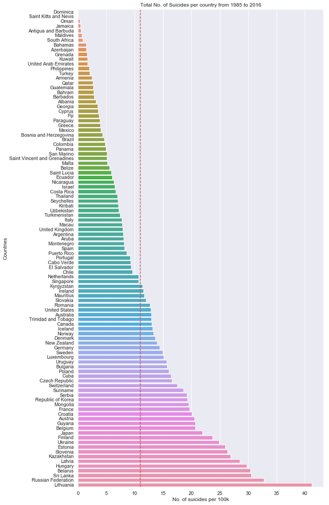

```python
def suicides_per_100k():
    df_country=df.groupby(["country"],as_index=False)["population","suicides_no"].sum()
    df_country["suicides_per_100k"]=df_country["suicides_no"]/(df_country["population"]/100000)
    plt.figure(figsize=(10,20))
    plt.axvline(df_country["suicides_per_100k"].mean(), color='r', linestyle='--')
    df_country.sort_values('suicides_per_100k',inplace=True)
    sns.barplot(y=df_country["country"], x=df_country["suicides_per_100k"])
    plt.xlabel('No. of suicides per 100k')
    plt.ylabel('Countries')
    plt.title('Total No. of Suicides per country from 1985 to 2016')
    return(plt.show())
suicides_per_100k()
```

**Insights :-**

**Lithuania’s** rate has been highest by a large margin: > 40 suicides per 100k (per year)

**Russian Federation** rate has been second highest > 30 suicides per 100k (per year)

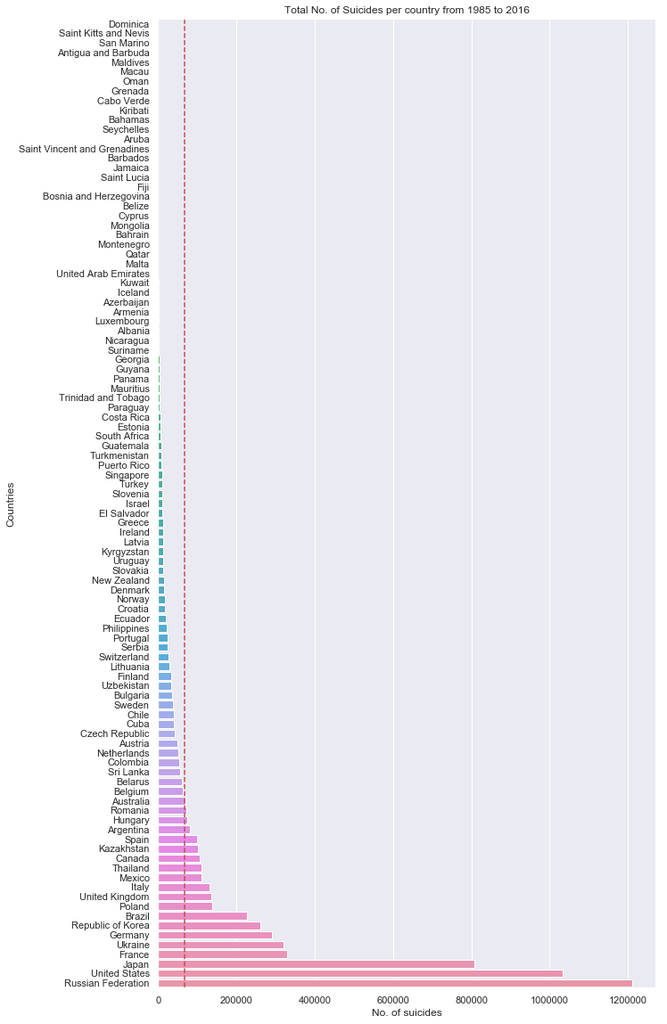

```python
def max_suicide():
    df_country=df.groupby(["country"],as_index=False)["population","suicides_no"].sum()
    plt.figure(figsize=(10,20))
    plt.axvline(df_country["suicides_no"].mean(), color='r', linestyle='--')
    df_country.sort_values('suicides_no',inplace=True)
    sns.barplot(y=df_country["country"], x=df_country["suicides_no"])
    plt.xlabel('No. of suicides')
    plt.ylabel('Countries')
    plt.title('Total No. of Suicides per country from 1985 to 2016')
    return(plt.show())
max_suicide()
```

**Insights :-**

Countries with highest **Number of Suicides** are :

- France
- Japan
- Russian Federation
- United States

### Based on above list let's check the record of last 10 years

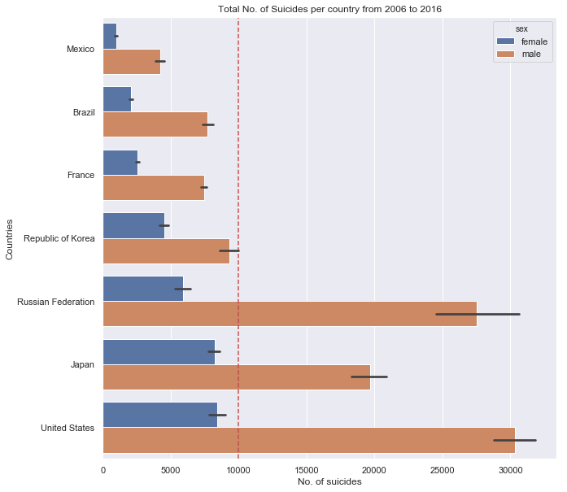

```python
def past_ten_years():
    df_country=df.groupby(["country","year","sex"],as_index=False)["population","suicides_no"].sum()
    df_s=df_country[df_country["year"] > 2005]
    stage = df_s.loc[df_country['country'].isin(["Mexico","Republic of Korea","France","Japan","Russian Federation","United States","Brazil"])]



    plt.figure(figsize=(10,10))
    plt.axvline(stage["suicides_no"].mean(), color='r', linestyle='--')
    stage.sort_values('suicides_no',inplace=True)
    sns.barplot(y=stage["country"], x=stage["suicides_no"],hue=stage["sex"])
    plt.xlabel('No. of suicides')
    plt.ylabel('Countries')
    plt.title('Total No. of Suicides per country from 2006 to 2016')
    return(plt.show())
past_ten_years()
```

**Insight :-**

**According to the data, Males are more prone to commit suicide.**

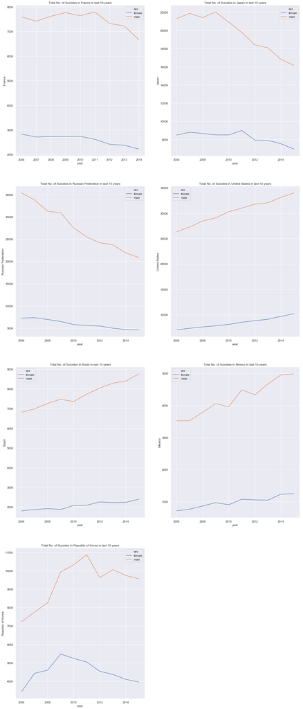

```python
def gender():
    df_country=df.groupby(["country","year","sex"],as_index=False)["population","suicides_no"].sum()
    df_s=df_country[df_country["year"] > 2005]
    france = df_s.loc[df_country['country'].isin(["France"])]
    RF = df_s.loc[df_country['country'].isin(["Russian Federation"])]
    US = df_s.loc[df_country['country'].isin(["United States"])]
    Japan = df_s.loc[df_country['country'].isin(["Japan"])]
    brazil = df_s.loc[df_country['country'].isin(["Brazil"])]
    mexico = df_s.loc[df_country['country'].isin(["Mexico"])]
    RK = df_s.loc[df_country['country'].isin(["Republic of Korea"])]

    plt.figure(figsize=(20,50))

    plt.subplot(421)
    sns.lineplot(y="suicides_no", x="year",hue="sex", data=france)
    plt.ylabel('France')
    plt.title('Total No. of Suicides in France in last 10 years')


    plt.subplot(422)
    sns.lineplot(y="suicides_no", x="year",hue="sex", data=Japan)
    plt.ylabel('Japan')
    plt.title('Total No. of Suicides in Japan in last 10 years')


    plt.subplot(423)
    sns.lineplot(y="suicides_no", x="year",hue="sex", data=RF)
    plt.ylabel('Russian Federation')
    plt.title('Total No. of Suicides in Russian Federation in last 10 years')


    plt.subplot(424)
    sns.lineplot(y="suicides_no", x="year",hue="sex", data=US)
    plt.ylabel('United States')
    plt.title('Total No. of Suicides in United States in last 10 years')


    plt.subplot(425)
    sns.lineplot(y="suicides_no", x="year",hue="sex", data=brazil)
    plt.ylabel('Brazil')
    plt.title('Total No. of Suicides in Brazil in last 10 years')


    plt.subplot(426)
    sns.lineplot(y="suicides_no", x="year",hue="sex", data=mexico)
    plt.ylabel('Mexico')
    plt.title('Total No. of Suicides in Mexico in last 10 years')


    plt.subplot(427)
    sns.lineplot(y="suicides_no", x="year",hue="sex", data=RK)
    plt.ylabel('Republic of Korea')
    plt.title('Total No. of Suicides in Republic of Korea in last 10 years')


    return(plt.show())
gender()
```

**Insights :-**

Over past **10** years;

### Lets check the countries with increasing trend suicide

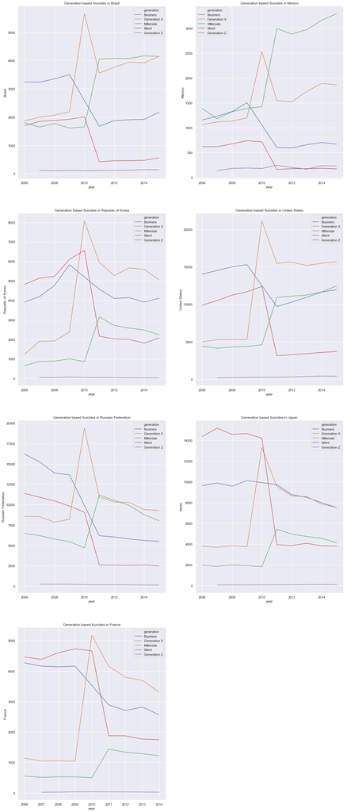

```python
def generations():
    df_country = df.groupby(["country","year","generation"],as_index=False)["population","suicides_no"].sum()
    df_s = df_country[df_country["year"] > 2005]

    brazil = df_s.loc[df_country['country'].isin(["Brazil"])]
    mexico = df_s.loc[df_country['country'].isin(["Mexico"])]
    US = df_s.loc[df_country['country'].isin(["United States"])]
    RK = df_s.loc[df_country['country'].isin(["Republic of Korea"])]
    france = df_s.loc[df_country['country'].isin(["France"])]
    RF = df_s.loc[df_country['country'].isin(["Russian Federation"])]
    Japan = df_s.loc[df_country['country'].isin(["Japan"])]

    plt.figure(figsize=(20,50))

    plt.subplot(421)
    sns.lineplot(y="suicides_no", x="year",hue="generation", data=brazil)
    plt.ylabel('Brazil')
    plt.title('Generation based Suicides in Brazil')


    plt.subplot(422)
    sns.lineplot(y="suicides_no", x="year",hue="generation", data=mexico)
    plt.ylabel('Mexico')
    plt.title('Generation based Suicides in Mexico')


    plt.subplot(423)
    sns.lineplot(y="suicides_no", x="year",hue="generation", data=RK)
    plt.ylabel('Republic of Korea')
    plt.title('Generation based Suicides in Republic of Korea')


    plt.subplot(424)
    sns.lineplot(y="suicides_no", x="year",hue="generation", data=US)
    plt.ylabel('United States')
    plt.title('Generation based Suicides in United States')


    plt.subplot(425)
    sns.lineplot(y="suicides_no", x="year",hue="generation", data=RF)
    plt.ylabel('Russian Federation')
    plt.title('Generation based Suicides in Russian Federation')


    plt.subplot(426)
    sns.lineplot(y="suicides_no", x="year",hue="generation", data=Japan)
    plt.ylabel('Japan')
    plt.title('Generation based Suicides in Japan')


    plt.subplot(427)
    sns.lineplot(y="suicides_no", x="year",hue="generation", data=france)
    plt.ylabel('France')
    plt.title('Generation based Suicides in France')


    return(plt.show())
generations()
```

**Insights :-**

**Generation X (with high peak around 2010)** and **Millenials(with rapid increase around 2010)** shows high potential as compared to other generations;

**Silent (with rapid decrease around 2010)** and **Boomers** shows significant decrease in suicide rate;

whereas, **Generation Z** follows constant trend.

**2010 is a interesting year, need to learn about it more.**

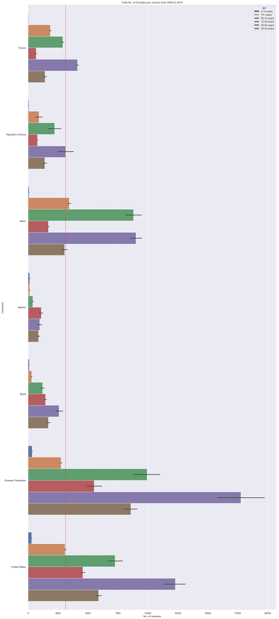

```python
def age():
    df_country=df.groupby(["country","year","age"],as_index=False)["population","suicides_no"].sum()
    df_s=df_country[df_country["year"] > 2005]
    stage = df_country.loc[df_country['country'].isin(["Mexico","Republic of Korea","France","Japan","Russian Federation","United States","Brazil"])]



    plt.figure(figsize=(20,50))
    plt.axvline(stage["suicides_no"].mean(), color='r', linestyle='--')
    stage.sort_values('suicides_no',inplace=True)
    sns.barplot(y=stage["country"], x=stage["suicides_no"],hue=stage["age"])
    plt.xlabel('No. of suicides')
    plt.ylabel('Countries')
    plt.title('Total No. of Suicides per country from 2006 to 2016')
    return(plt.show())
age()
```

**Insights :-**

Age groups like **35-54 years** and **55-74 years** are dominating our data.

Youth between **25-34 years** are also can not be neglected.

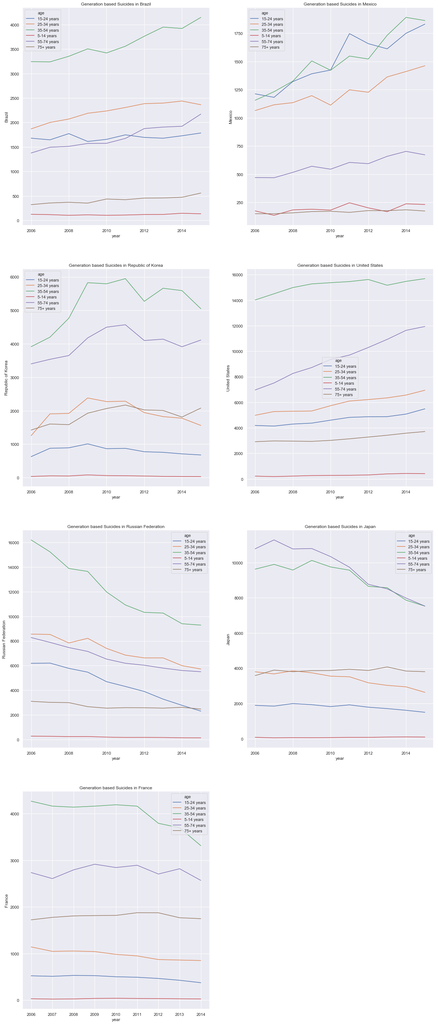

```python
def ages():
    df_country = df.groupby(["country","year","age"],as_index=False)["population","suicides_no"].sum()
    df_s = df_country[df_country["year"] > 2005]

    brazil = df_s.loc[df_country['country'].isin(["Brazil"])]
    mexico = df_s.loc[df_country['country'].isin(["Mexico"])]
    US = df_s.loc[df_country['country'].isin(["United States"])]
    RK = df_s.loc[df_country['country'].isin(["Republic of Korea"])]
    france = df_s.loc[df_country['country'].isin(["France"])]
    RF = df_s.loc[df_country['country'].isin(["Russian Federation"])]
    Japan = df_s.loc[df_country['country'].isin(["Japan"])]

    plt.figure(figsize=(20,50))

    plt.subplot(421)
    sns.lineplot(y="suicides_no", x="year",hue="age", data=brazil)
    plt.ylabel('Brazil')
    plt.title('Generation based Suicides in Brazil')


    plt.subplot(422)
    sns.lineplot(y="suicides_no", x="year",hue="age", data=mexico)
    plt.ylabel('Mexico')
    plt.title('Generation based Suicides in Mexico')


    plt.subplot(423)
    sns.lineplot(y="suicides_no", x="year",hue="age", data=RK)
    plt.ylabel('Republic of Korea')
    plt.title('Generation based Suicides in Republic of Korea')


    plt.subplot(424)
    sns.lineplot(y="suicides_no", x="year",hue="age", data=US)
    plt.ylabel('United States')
    plt.title('Generation based Suicides in United States')


    plt.subplot(425)
    sns.lineplot(y="suicides_no", x="year",hue="age", data=RF)
    plt.ylabel('Russian Federation')
    plt.title('Generation based Suicides in Russian Federation')


    plt.subplot(426)
    sns.lineplot(y="suicides_no", x="year",hue="age", data=Japan)
    plt.ylabel('Japan')
    plt.title('Generation based Suicides in Japan')


    plt.subplot(427)
    sns.lineplot(y="suicides_no", x="year",hue="age", data=france)
    plt.ylabel('France')
    plt.title('Generation based Suicides in France')


    return(plt.show())
ages()
```

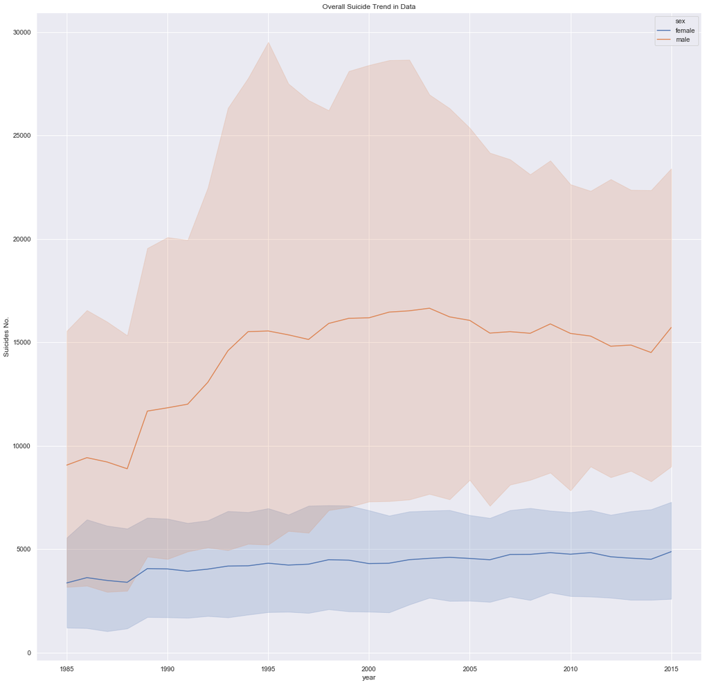

```python
def overall():
    df_country=df.groupby(["country","year","sex"],as_index=False)["population","suicides_no"].sum()
    df_s=df_country[df_country["year"] > 2005]
    stage = df_country.loc[df_country['country'].isin(["Mexico","Republic of Korea","France","Japan","Russian Federation","United States","Brazil"])]

    plt.figure(figsize=(20,20))
    g = sns.lineplot(y="suicides_no", x="year",hue="sex", data=stage)
    plt.ylabel('Suicides No.')
    plt.title('Overall Suicide Trend in Data')

    return(g)
overall()
```

### Does GDP and Population of the country affects the suicide rate?

```
2136.2286117616113
[-0.03972663]
Y = [-0.03972663] X + 2136.2286117616113
```

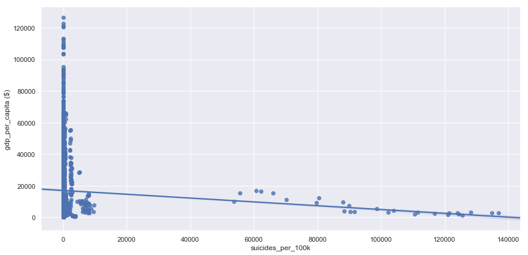

```python
def gdp():
    df_gdp = df.groupby(["country","year","gdp_per_capita ($)"],as_index=False)["population","suicides_no"].sum()
    df_gdp["suicides_per_100k"] = df_gdp["suicides_no"]/(df_country["population"]/100000)
    sns.pairplot(df_gdp, x_vars=['suicides_per_100k'], y_vars=["gdp_per_capita ($)"], height=6, aspect=2, kind='reg')
    X = df_gdp["gdp_per_capita ($)"].values.reshape(-1,1)
    y = df_gdp["suicides_per_100k"]
    from sklearn.linear_model import LinearRegression
    lm = LinearRegression()
    lm.fit(X,y)
    print(lm.intercept_)
    print(lm.coef_)
    print("Y = {}".format(lm.coef_),"X + {}".format(lm.intercept_))
gdp()
```

**Insights :-**

A weak relation, as can be seen in the above graph; let's evaluate.

X = GDP per Capita ($)

Y = Suicides per 100k

Not a very good regresssion, as correaltion is very weak.